# Reproducible Pitch

Rabiya Ali

2018 03 25

## Coursera Reproducible Pitch

Your presentation must satisfy the following

It must be done in Slidify or Rstudio Presenter It must be 5 pages It must be hosted on github or Rpubs It must contained some embedded R code that gets run when slidifying the document NOTE: Slidify is no longer compatible with with Rpubs. If you choose to use Slidify you must share your presentation using GitHub Pages.

Notice to publish your slidify presentation to github or Rpubs, there’s the publish command. This link outlines how to do it (it’s one line).

http://slidify.org/publish.html

Rstudio presenter has a button to publish directly to Rpubs https://support.rstudio.com/hc/en-us/articles/200714023-Displaying-and-Distributing-Presentations. If you are using Rpubs, put in the link to the presentation into the submission box as a http:// link not a https:// link.

You can also publish using both formats to github manually using gh-pages, though your github branch must have a .nojekyll fle and be on a branch names gh-pages. There’s more on gh-pages here https://pages.github.com/ and there is a video lecture outlining how to do this.

## Source

Handerson and Valleman (1981), Building multiple regression model, Biometrics, 37, 391-411

# ## Slide with R Output

```r
summary(cars)
```

```
##      speed           dist
##  Min.   : 4.0   Min.   :  2.00
##  1st Qu.:12.0   1st Qu.: 26.00
##  Median :15.0   Median : 36.00
##  Mean   :15.4   Mean   : 42.98
##  3rd Qu.:19.0   3rd Qu.: 56.00
##  Max.   :25.0   Max.   :120.00
```

# ## Slide with Plot

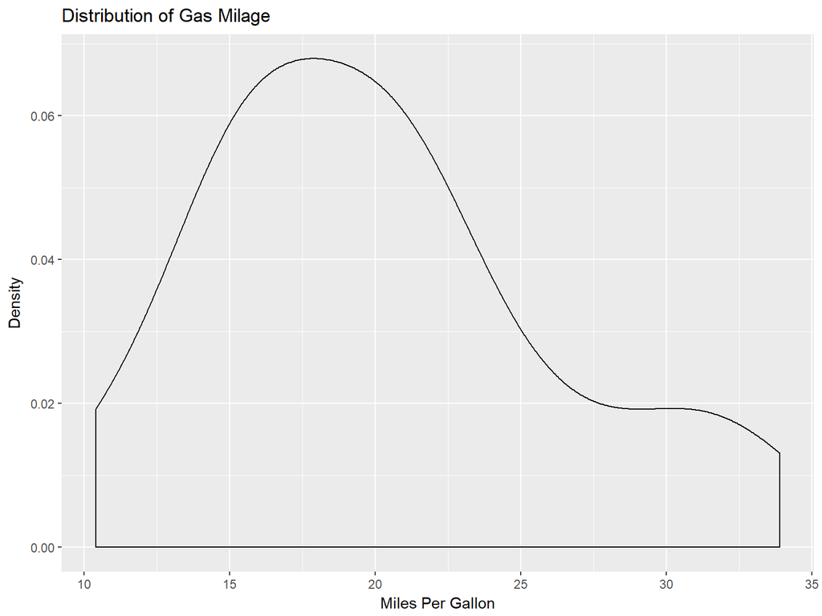

# Shiny files

The application is build using Shiny package and the source code is in 2 files: - `ui.R` - `server.R`

Both files can be found here: [GitHub repo](https://github.com/avkch/Course-Project-Shiny-Application-and-Reproducible-Pitch)